# The Malaysia Statutory Fiscal-Change Dataset

An LLM-assisted, expert-validated dataset of corporate, personal, and consumption tax changes, discretionary government spending shocks, and tax-incentive changes (1990–2023)

Authors

Affiliations

[Esteban Degetau](https://www.estebandegetau.com/)

World Bank

Barcelona School of Economics

[Agustín Samano](https://www.worldbank.org/en/about/people/a/agustin-samano)

World Bank

Published

October 30, 2026

Abstract

We build an LLM-assisted pipeline that transfers the narrative identification framework of Romer and Romer (2010) to developing countries, and we hold it to a robust validation discipline. Country-agnostic codebooks are validated against 44 labelled US acts (1945-2003) through behavioral tests, zero-shot evaluation and manual error analysis, then frozen and deployed to Malaysia (1980–2023), where an agentic identification layer produces an expert-ready inventory of 51 statutory tax, spending and tax-incentive events, each carrying a magnitude, a motivation, a direction and two independent preliminary reads of exogeneity. With no motivation ground truth available, transfer is evidenced three ways: a bilingual corpus that returns comparable inventories in English and Bahasa Malaysia, worked disagreement cases printed in full, and statutory rate paths that reproduce the Vegh and Vuletin (2015) cross-country rate panel exactly wherever the corpus is dense, with every miss predating corpus coverage and every extra an act a top-rate series cannot represent. We demonstrate the dataset with a procyclicality decomposition: Malaysia’s statutory-rate cyclicality is statistically indistinguishable from zero, as is the median country’s in the same panel, while the narrative labels show that the great majority of Malaysian fiscal actions whose timing looks procyclical carried motivations unrelated to the cycle. We report that as a demonstration and bound it with a label-fragility index rather than a p-value. The exogeneity column is a model read pending expert adjudication, and magnitude and quarterly timing carry no validation record; we state throughout which stages rest on evidence and which do not.

Keywords

Fiscal policy, Narrative analysis, AI for social science

```r
pacman::p_load(targets, tidyverse, tinytable, here, scales)

here::i_am("notebooks/malaysia_dataset.qmd")
tar_config_set(store = here("_targets"))
source(here("R/tt_theme.R"))
source(here("R/malay_consistency.R"))   # pretty_motivation() + motivation palette
source(here("R/tax_shock_report.R"))
source(here("R/spending_shock_report.R"))   # reuses the tax helpers' internals
source(here("R/incentive_shock_report.R"))  # reuses the tax helpers' internals
set_theme(theme_minimal())

tax_shocks       <- tryCatch(tar_read(tax_shocks), error = function(e) tibble::tibble())
have_data        <- nrow(tax_shocks) > 0
spending_shocks  <- tryCatch(tar_read(spending_shocks), error = function(e) tibble::tibble())
have_spending    <- nrow(spending_shocks) > 0
incentive_shocks <- tryCatch(tar_read(incentive_shocks), error = function(e) tibble::tibble())
have_incentives  <- nrow(incentive_shocks) > 0
```

This page accompanies the dataset of **statutory fiscal changes for Malaysia** built for *“Scaling Narrative Fiscal Shock Identification with LLMs”* (Degetau & Samano, World Bank). It is written for the reviewer: it shows the headline picture, lets you download the data, walks several acts in full, and explains how the dataset was produced. It covers both sides of the budget: **statutory tax changes** and **discretionary government spending shocks**.

Each row is **one narratively-announced act × instrument**. On the tax side an instrument is a corporate income tax (CIT), personal income tax (PIT), or broad consumption tax (CONSUMPTION = VAT/GST/SST) change, carrying the statutory rate change. On the spending side it is a discretionary expenditure measure — a stimulus or relief package, a subsidy-policy change, or a large allocation — carrying a magnitude in ringgit rather than a rate. Both carry a motivation label and an exogenous/endogenous read produced with the validated C2b codebook. The unit of observation and the motivation taxonomy follow the narrative approach of Romer and Romer (2010); the LLM pipeline that produces them is validated with the framework of Halterman and Keith (2025). Spending exogeneity additionally carries a preliminary read from the two-condition screen of Das et al. (2026) (non-cyclical motive and no contemporaneous macro rationale), kept alongside the C2b verdict.

**Important**

**Exogeneity here is a preliminary input, not a finding.** The exogenous/endogenous classification is the LLM’s read of the narrative record and is provided to *assist* an expert, not to replace one. It is pending expert adjudication. Throughout the project we keep the human in the loop: the model proposes, the expert disposes. The two worked examples below were both chosen because the model’s read and the preliminary narrative read disagree — exactly the cases an expert must settle.

# 1 Statutory tax changes

## 1.1 Tax changes at a glance

```r
tax_inventory_table(tax_shocks)
```

Table 1: **Statutory tax-change inventory.** One row per announced act × tax type. Δpp is the change in the headline statutory rate; motivation and the exogenous/endogenous read are from the validated C2b codebook (v0.9.1).

| Act | Year | Tax | Δpp | Motivation | Exogenous |
| --- | --- | --- | --- | --- | --- |
| Corporate income tax rate reduction 34% to 32% (early-1990s Budget) | 1994 | CIT | -2 | Long-run | Exogenous |
| Corporate income tax rate reduction 32% to 30% (mid-1990s Budget) | 1995 | CIT | -2 | Long-run | Exogenous |
| Corporate income tax rate reduction 30% to 28% (Budget 1998) | 1998 | CIT | -2 | Countercyclical | Endogenous |
| Corporate income tax rate reduction 28% to 27% (Budget 2007) | 2007 | CIT | -1 | Long-run | Exogenous |
| Corporate income tax rate reduction 27% to 26% (Budget 2007) | 2008 | CIT | -1 | Long-run | Exogenous |
| Single-tier corporate tax system (Budget 2008) | 2008 | CIT | NA | Long-run | Exogenous |
| Corporate income tax rate reduction 26% to 25% (Budget 2008) | 2009 | CIT | -1 | Long-run | Exogenous |
| Corporate income tax rate reduction 25% to 24% (Budget 2015) | 2016 | CIT | -1 | Deficit-driven | Exogenous |
| Cukai Makmur one-off prosperity tax surcharge (Budget 2022) | 2022 | CIT | 9 | Deficit-driven | Exogenous |
| Service tax rate increase 5% to 6% (Budget 2011) | 2011 | CONSUMPTION | 1 | Deficit-driven | Exogenous |
| Goods and Services Tax (GST) introduction at 6% (Budget 2014) | 2015 | CONSUMPTION | 6 | Deficit-driven | Exogenous |
| GST abolition / zero-rating 6% to 0% (Pakatan Harapan reform, 2018) | 2018 | CONSUMPTION | -6 | Countercyclical | Endogenous |
| Sales and Service Tax (SST) reintroduction (2018) | 2018 | CONSUMPTION | NA | Countercyclical | Endogenous |
| Across-the-board individual income tax cut 1pp (Budget 2000) | 2000 | PIT | -1 | Long-run | Exogenous |
| Top individual income tax rate reduction 29% to 28% (Budget 2002) | 2002 | PIT | -1 | Countercyclical | Endogenous |
| Top individual income tax rate reduction 28% to 27% (Budget 2009) | 2009 | PIT | -1 | Long-run | Exogenous |
| Top individual income tax rate reduction 27% to 26% (Budget 2010) | 2010 | PIT | -1 | Long-run | Exogenous |
| Individual income tax restructure, top rate 26% to 25% (Budget 2014, GST-offset) | 2015 | PIT | -1 | Long-run | Exogenous |
| High-earner individual income tax hike 25% to 28% above RM1m (Budget 2016) | 2016 | PIT | 3 | Deficit-driven | Exogenous |
| Middle-band individual income tax cut 2pp, RM20k-70k (Budget 2018) | 2018 | PIT | NA | Long-run | Exogenous |
| New 30% top band above RM2m, 28% to 30% (Budget 2020) | 2020 | PIT | 2 | Long-run | Exogenous |
| Individual income tax restructure: M40 cut / T20 hike (Budget 2023) | 2023 | PIT | 0 | Countercyclical | Endogenous |

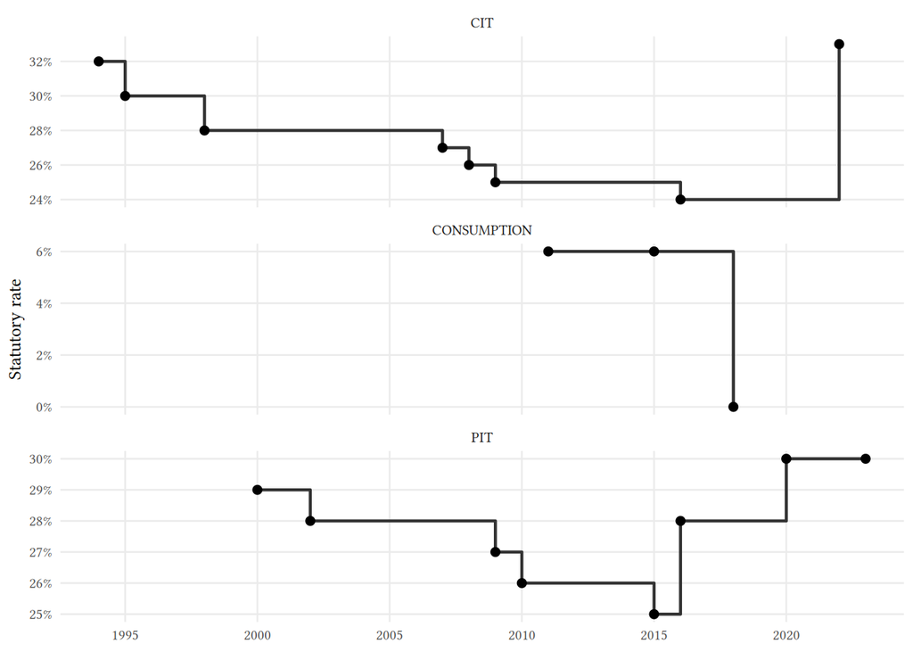

```r
plot_tax_rate_paths(tax_shocks)
```

Figure 2: **Tax-change timeline.** Acts per year × tax type as a diverging stacked bar: hikes grow the bar upward, cuts downward. Colour denotes the C2b motivation. Faceted by tax type.

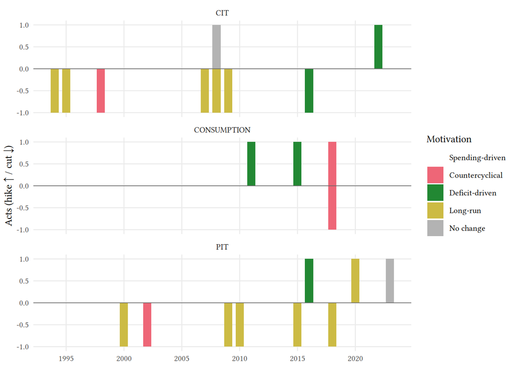

```r
plot_tax_timeline(tax_shocks)
```

## 1.2 Download the tax dataset

A clean, flat version of the dataset (one row per act × tax type, no nested provenance columns) is available in three formats. The Stata file carries variable labels; the Excel workbook includes a second sheet with the data dictionary reproduced below.

- Download CSV
- Download Excel (.xlsx, with data dictionary)
- Download Stata (.dta, labelled)

```r
tax_export_dictionary_table()
```

Table 2: **Data dictionary.** Columns of the downloadable dataset.

| Variable | Label | Definition |
| --- | --- | --- |
| shock_id | Shock identifier | Unique ID, one per announced act x tax type (e.g. MY-CIT-03). |
| act_label | Act / event name | Human-readable name of the announced act or budget measure. |
| tax_type | Tax instrument | CIT (corporate income), PIT (personal income), or CONSUMPTION (VAT/GST/SST). |
| direction | Direction of change | Cut, Hike, or Neutral; consistent with the sign of delta_pp. |
| rate_from | Statutory rate before (%) | Headline statutory rate prior to the change; NA if not a rate change. |
| rate_to | Statutory rate after (%) | Headline statutory rate after the change; NA if not a rate change. |
| delta_pp | Rate change (pp) | rate_to minus rate_from, in percentage points; NA if non-rate. |
| announced_year | Announcement year | Year the act was announced (budget year). |
| effective_year | Effective year | Year of assessment / year the change took effect. |
| effective_quarter | Effective quarter | Effective quarter (e.g. 2016Q1) where known; NA when only year is known. |
| motivation | Motivation (C2b) | Validated C2b motivation: Spending-driven, Countercyclical, Deficit-driven, or Long-run. |
| exogenous | Exogenous (C2b) | C2b exogenous/endogenous classification (TRUE = exogenous). Preliminary input pending expert adjudication. |

## 1.3 Two tax acts in full

To show how the dataset is built act-by-act, we reproduce two narrative summaries in the style of Romer and Romer (2010) (their Exhibits 1 and 2, p. 772): a header with the classification, the identification and motivation reasoning, the most diagnostic source quotation, and links to the source documents. We deliberately picked two acts where the model’s classification and the preliminary narrative read **diverge** — the methodologically consequential cases.

### 1.3.1 An endogenous act: the 1998 corporate tax cut

The Budget 1998 corporate tax cut (30% → 28%, announced October 1997) is an **omnibus** budget act: alongside the headline CIT cut it bundled import-duty changes and productivity incentives. Asked for the sign of the effect on tax liabilities, the model returned `"mixed"` — a value outside the permitted `{increase, decrease, no_change}` set, because the package has no single sign. The pipeline degrades gracefully: it keeps the otherwise-valid classification (countercyclical, endogenous) and records the signed effect as `NA`, preserving the raw `"mixed"` for the audit trail. The act also illustrates the preliminary-vs-model tension: read narrowly, the rate cut reads as a long-run competitiveness move (exogenous); read in its Asian-crisis context, the budget reads as cyclical stabilization (endogenous). This is the kind of call we hand to an expert.

**NoteExhibit 1 — Corporate income tax rate reduction 30% to 28% (Budget 1998)**

**Shock ID:** MY-CIT-03 | **Tax:** CIT | **Announced:** 1997 | **Effective:** 1998  
**Rate change:** 30% → 28% (-2 pp; Cut)  
**Classification (C2b):** Endogenous — Countercyclical  
**Signed effect on liabilities:** NA *(no single sign; raw model output: “mixed”)*

*Identification.* 30->28 reduction announced in the 1998 Budget (Oct 1997), effective YA1998. Evidence: BNM Annual Report 1997.

*Motivation (C2b).* The evidence consistently shows that the 1998 Budget and accompanying fiscal measures were designed to restore economic stability and return growth to normal in response to the 1997 Asian financial crisis and regional currency turmoil. Policymakers explicitly stated the goal was to ‘restore stability to overcome disruptions’, ‘address imbalances in the economy’, and ‘restore macroeconomic stability and investor confidence’ following the July 1997 currency crisis. While the package included some long-run structural elements (tax incentives for productivity and competitiveness), the predominant and repeatedly stated motivation across all evidence was cyclical stabilization in response to the regional financial shock and its effects on Malaysia’s economy (currency depreciation, banking vulnerabilities, current account deficit, inflation). The fiscal measures were explicitly framed as responses to current economic conditions and external shocks, not as structural reforms or deficit reduction from inherited imbalances. This satisfies the countercyclical criterion: actions taken to offset developments that would cause output growth to differ from normal.

> reduce the cost of doing business and strengthen competitiveness … reduced to 28% in 1998 compared with 30% each for Indonesia and Thailand

*Preliminary narrative read:* exogenous — **differs from the C2b verdict; this is exactly the kind of call an expert must adjudicate.**

**Sources:** [Bank Negara Malaysia Annual Report (1997, en)](https://www.bnm.gov.my/-/bnm-annual-report-1997)

### 1.3.2 An exogenous act: the 2000 personal income tax cut

The Budget 2000 across-the-board one-percentage-point cut to personal income tax illustrates the opposite tension. Coming shortly after the 1997–98 crisis, the preliminary narrative read flags it as part of a demand-recovery package (endogenous). The model, weighing the budget’s stated rationale — global competition (WTO, AFTA), R&D, human-capital and competitiveness — classifies it as a long-run, exogenous change. Again, the two reads are kept side by side for the expert.

**NoteExhibit 2 — Across-the-board individual income tax cut 1pp (Budget 2000)**

**Shock ID:** MY-PIT-01 | **Tax:** PIT | **Announced:** 1999 | **Effective:** 2000  
**Rate change:** 30% → 29% (-1 pp; Cut)  
**Classification (C2b):** Exogenous — Long-run  
**Signed effect on liabilities:** decrease (−)

*Identification.* Headline P1. Budget 2000 across-the-board 1pp cut; framed in BNM AR 1999 as part of the post-1997-98 crisis demand-recovery package -> preliminary endogenous (countercyclical). Top from/to inferred 30->29 (1pp cut applied to the documented 29% pre-2002 top); flagged, rate fields are the inferred top-marginal value.

*Motivation (C2b).* The 2000 Malaysian Budget’s primary stated motivation is to raise long-run growth and improve structural competitiveness, not to offset a cyclical downturn. Policymakers explicitly cite global competition (WTO, AFTA), technological change, low R&D spending relative to developed economies, and the need to improve human resource management and service-sector competitiveness. While consumption-support language appears, the overarching rationale is structural reform and raising potential output through improved incentives and efficiency. The evidence does not characterize current conditions as requiring cyclical stimulus to return growth to normal; rather, it frames the measures as long-run structural improvements to enable Malaysia to compete globally and sustain higher growth.

> one percentage point across-the-board reduction in personal income tax rates, higher tax relief and salary adjustments … real aggregate domestic demand is expected to strengthen (BNM AR 1999, 2000 Budget recovery context)

*Preliminary narrative read:* endogenous — **differs from the C2b verdict; this is exactly the kind of call an expert must adjudicate.**

**Sources:** [Bank Negara Malaysia Annual Report (1999, en)](https://www.bnm.gov.my/-/bnm-annual-report-1999); [Budget Speech / Ucapan Bajet (2000, en)](https://belanjawan.mof.gov.my/en/archive)

# 2 Government spending shocks

The dataset also covers **discretionary government spending shocks**: major spending actions announced in budgets and crisis responses — stimulus and relief packages, subsidy-policy changes, and large allocations. Unlike a tax change there is no statutory rate, so the magnitude is recorded in ringgit (or as a share of expenditure) as free text rather than as a rate change, and the direction is an increase or decrease in spending. The motivation and the exogenous/endogenous read again come from the validated C2b codebook; a preliminary read from the Das et al. (2026) two-condition screen is carried alongside. Routine baseline development expenditure (for example the standing Five-Year Plan framework) is deliberately excluded — only discretionary changes count as shocks.

## 2.1 Spending shocks at a glance

```r
spending_inventory_table(spending_shocks)
```

Table 3: **Government spending-shock inventory.** One row per announced spending act. The exogenous/endogenous read is from the validated C2b codebook (v0.9.1); category, magnitude, and motivation appear in the exhibit and downloads.

| Act | Effective | Exogenous |
| --- | --- | --- |
| National Economic Recovery Plan (NERP) (1998) | 1998 | Endogenous |
| Pre-emptive fiscal stimulus package, RM3bn (March 2001) | 2001 | Endogenous |
| Additional fiscal stimulus package, RM4.3bn (September 2001) | 2001 | Endogenous |
| Fuel-subsidy restructuring (June 2008) | 2008 | Exogenous |
| First Economic Stimulus Package, RM7bn (November 2008) | 2009 | Endogenous |
| Second Economic Stimulus Package, RM60bn (March 2009 mini-budget) | 2009 | Endogenous |
| Subsidy rationalisation programme (2010- ) | 2010 | Exogenous |
| 1Malaysia/Keluarga cash-transfer programme (BR1M -> BKM, 2012- ) | 2012 | Endogenous |
| PRIHATIN Rakyat economic stimulus package (2020) | 2020 | Endogenous |
| PENJANA short-term economic recovery plan (2020) | 2020 | Endogenous |
| PERMAI assistance package (2021) | 2021 | Endogenous |
| PEMERKASA programme (2021) | 2021 | Endogenous |
| PEMERKASA+ package (2021) | 2021 | Endogenous |
| PEMULIH package (2021) | 2021 | Endogenous |

Figure 3: **Spending-shock timeline.** Acts per year as a diverging stacked bar: spending increases grow the bar upward, decreases downward. Colour denotes the C2b exogenous/endogenous classification. A single panel (no per-category facet): the spending mix is dominated by crisis-response packages.

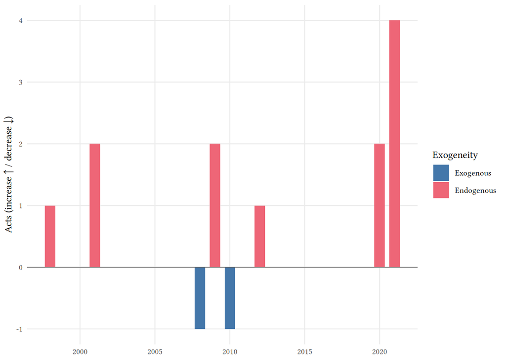

```r
plot_spending_timeline(spending_shocks)
```

## 2.2 Download the spending dataset

The spending dataset is available in the same three formats as the tax dataset (one row per spending act, no nested provenance columns). The Stata file carries variable labels; the Excel workbook includes a second sheet with the data dictionary reproduced below.

- Download CSV
- Download Excel (.xlsx, with data dictionary)
- Download Stata (.dta, labelled)

```r
spending_export_dictionary_table()
```

Table 4: **Spending data dictionary.** Columns of the downloadable spending dataset.

| Variable | Label | Definition |
| --- | --- | --- |
| shock_id | Shock identifier | Unique ID, one per announced spending act (e.g. MY-SPEND-04). |
| act_label | Act / package name | Human-readable name of the spending act, package, or policy change. |
| spending_category | Spending category | Das component family: Infrastructure investment, Social transfers, Subsidies, Public wages, Consolidation/restraint, or Other. |
| direction | Direction of change | Increase (expansionary), Decrease (contractionary), or Neutral. |
| magnitude_note | Magnitude (free text) | Headline magnitude in RM or percent terms (e.g. RM60 bn); spending has no statutory rate. |
| announced_year | Announcement year | Year the act / package was announced. |
| effective_year | Effective year | Year the spending change took effect. |
| effective_quarter | Effective quarter | Effective quarter (e.g. 2020Q1) where known; NA when only year is known. |
| motivation | Motivation (C2b) | Validated C2b motivation: Spending-driven, Countercyclical, Deficit-driven, or Long-run. |
| exogenous | Exogenous (C2b) | C2b exogenous/endogenous classification (TRUE = exogenous). Preliminary input pending expert adjudication. |

## 2.3 A spending act in full

As on the tax side, we reproduce one spending act in full, again choosing a case where the model’s classification and the preliminary narrative read **diverge**.

The June 2008 fuel-subsidy restructuring cut a major subsidy in response to a global crude-oil price spike that had made the subsidy bill fiscally unsustainable. The preliminary Das et al. (2026) screen, seeing a contemporaneous macro trigger, reads it as endogenous; the C2b model, weighing the deficit-reduction rationale, reads it as exogenous and deficit-driven. The two reads are kept side by side for the expert.

**NoteExhibit 3 — Fuel-subsidy restructuring (June 2008)**

**Shock ID:** MY-SPEND-04 | **Category:** Subsidies | **Announced:** 2008 | **Effective:** 2008Q2  
**Change:** Decrease — Retail fuel prices raised ~40.4% in June 2008 as the global crude-oil spike made the subsidy fiscally unsustainable; partial offsets (rice subsidy, fishermen/transport fuel subsidy, motorist fuel cash rebate).  
**Classification (C2b):** Exogenous — Deficit-driven  
**Signed effect (C2b):** decrease (−)

*Identification.* Distinct from the 2010 structural rationalisation (reviewer decision: separate row). Driven by the 2008 oil-price spike / financing pressure on the subsidy bill -> cyclical/price-driven -> endogenous.

*Motivation (C2b).* The fuel subsidy restructuring was motivated primarily by fiscal sustainability concerns, not by contemporaneous spending changes or cyclical conditions. Evidence explicitly states the government restructured subsidies to ‘avoid prolonged high fiscal deficit’ and because subsidy costs had risen unsustainably from RM1.7 billion (2002) to RM7.5 billion (2007), projected to reach RM28 billion in 2008, ‘threatening fiscal sustainability.’ While mitigation measures (cash rebates, targeted subsidies) were introduced to cushion the impact on citizens, these were secondary responses to the primary deficit-reduction motivation. The action addresses an inherited fiscal burden from past subsidy commitments at volatile global oil prices, not a contemporaneous spending increase or cyclical downturn.

> The fuel subsidy restructuring exercise undertaken by the Government in June caused fuel prices to increase by 40.4%, resulting in a sharp increase in the headline inflation rate, which peaked at 8.5% in July.

*Preliminary narrative read (Das screen):* endogenous — **differs from the C2b verdict; this is exactly the kind of call an expert must adjudicate.**

**Sources:** [Bank Negara Malaysia Annual Report (2008, en)](https://www.bnm.gov.my/-/bnm-annual-report-2008); [Economic Report / Tinjauan Ekonomi (2009, en)](https://www.mof.gov.my/portal/arkib/ekonomi/ek_main.html)

# 3 Tax incentives and holidays

The dataset also covers **changes to tax incentives and holidays**: tax holidays (Pioneer Status), investment and reinvestment allowances, concessionary investor rates (Labuan, Principal Hub, sectoral special rates), free/export/enterprise zones, and consumption- and personal-side reliefs. These differ from a statutory rate change in being *targeted* (conditional on investor, sector, region, or activity), often *time-bounded*, and frequently operating through the tax base or a carve-out rate rather than the standing rate — so each event lives here rather than in the tax tables (ownership-by-mechanism). The unit is one row per legislative *change*; the standing existence of a long-running scheme is not a shock. The motivation and the exogenous/endogenous read again come from the validated C2b codebook; a preliminary read is carried alongside. Incentives skew exogenous — FDI-attraction, industrial policy, and structural competitiveness are long-run motives.

## 3.1 Incentive changes at a glance

```r
incentive_inventory_table(incentive_shocks)
```

Table 5: **Tax-incentive shock inventory.** One row per announced incentive change. The exogenous/endogenous read is from the validated C2b codebook (v0.9.1); direction, rate detail, magnitude, and motivation appear in the exhibit and downloads.

| Act | Category | Base | Year | Exogenous |
| --- | --- | --- | --- | --- |
| DEB equity-restructuring 5pp CIT exemption | Preferential rate | CIT | 1980 | Exogenous |
| Promotion of Investments Act 1986 (Pioneer Status / ITA framework) | Tax holiday | CIT | 1986 | Exogenous |
| Labuan IOFC / LOBATA 1990 offshore regime | Preferential rate | CIT | 1990 | Exogenous |
| Reinvestment Allowance increase (Budget 1994) | Investment allowance | CIT | 1994 | Exogenous |
| MSC / Multimedia Super Corridor status incentives | Tax holiday | CIT | 1996 | Exogenous |
| Biomass-based generation income-tax exemption (Budget 2001) | Sectoral / R&D | CIT | 2001 | Exogenous |
| Iskandar Malaysia (WPI/IDR) zone incentives | Zone incentive | CIT | 2007 | Exogenous |
| Green Building Index (GBI) income-tax exemption (Budget 2010) | Sectoral / R&D | CIT | 2010 | Exogenous |
| KLIFD / Tun Razak Exchange financial-district incentives (Budget 2012) | Tax holiday | CIT | 2012 | Exogenous |
| Angel-investor & venture-capital tax incentives | Other | PIT | 2013 | Exogenous |
| Principal Hub 10% concessionary rate (Budget 2019) | Preferential rate | CIT | 2019 | Exogenous |
| Companies-relocating-to-Malaysia incentive (PENJANA / Budget 2021) | Preferential rate | CIT | 2020 | Endogenous |
| Pharmaceutical/vaccine 0-10% preferential rate (Budget 2021) | Preferential rate | CIT | 2021 | Exogenous |
| Relocation incentive extension (Budget 2023) | Preferential rate | CIT | 2023 | Exogenous |
| Electric Vehicle (EV) tax incentives (Budget 2023) | Sectoral / R&D | Consumption | 2023 | Exogenous |

Figure 4: **Incentive-shock timeline.** Acts per year as a diverging stacked bar: new or expanded incentives grow the bar downward, repeals/scale-backs upward. Colour denotes the C2b exogenous/endogenous classification. A single panel (no per-base facet): incentives are dominated by the corporate base.

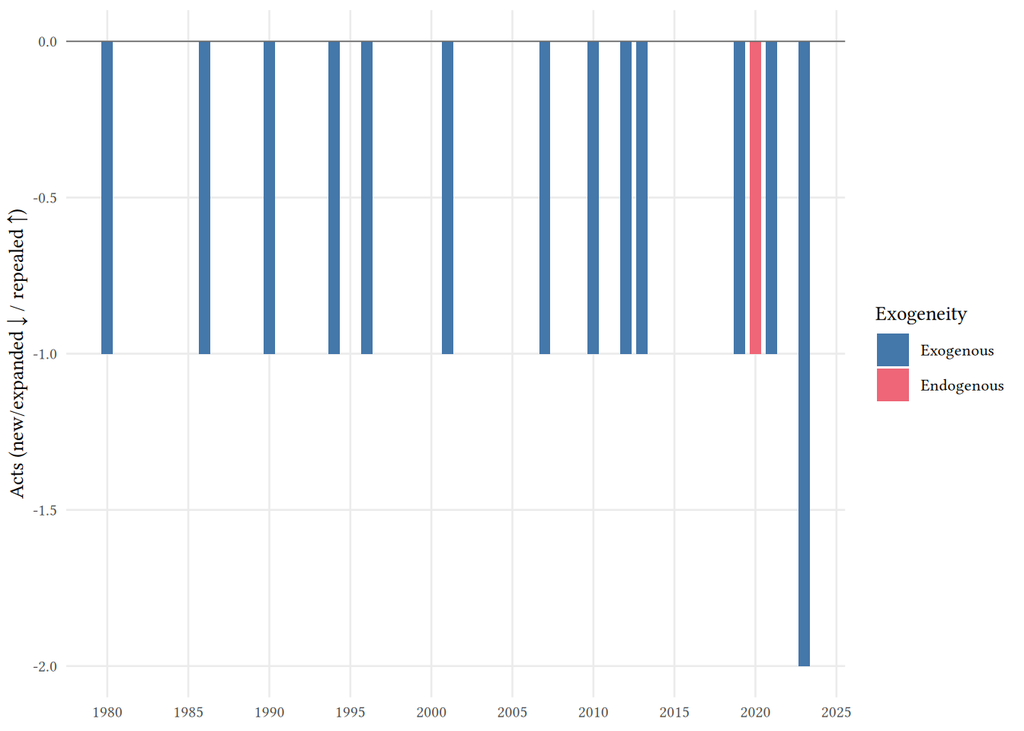

```r
plot_incentive_timeline(incentive_shocks)
```

## 3.2 Download the incentive dataset

The incentive dataset is available in the same three formats as the tax and spending datasets (one row per incentive change, no nested provenance columns). The Stata file carries variable labels; the Excel workbook includes a second sheet with the data dictionary reproduced below.

- Download CSV
- Download Excel (.xlsx, with data dictionary)
- Download Stata (.dta, labelled)

```r
incentive_export_dictionary_table()
```

Table 6: **Incentive data dictionary.** Columns of the downloadable incentive dataset.

| Variable | Label | Definition |
| --- | --- | --- |
| shock_id | Shock identifier | Unique ID, one per announced incentive change (e.g. MY-INCENT-03). |
| act_label | Act / measure name | Human-readable name of the incentive scheme, change, or budget measure. |
| tax_type | Underlying tax base | Tax base the incentive sits on: CIT, PIT, CONSUMPTION, or NA. |
| incentive_category | Incentive category | Mechanism family: Tax holiday, Investment allowance, Preferential rate, Zone incentive, Sectoral/R&D, or Other. |
| direction | Direction of change | Cut (new/expanded incentive, lowers effective burden), Hike (repeal/scale-back), or Neutral. |
| rate_from | Concessionary rate before (%) | Rate prior to the change for preferential-rate incentives; NA for non-rate incentives. |
| rate_to | Concessionary rate after (%) | Rate after the change for preferential-rate incentives; NA for non-rate incentives. |
| delta_pp | Rate change (pp) | rate_to minus rate_from, in percentage points; NA for non-rate incentives. |
| magnitude_note | Magnitude (free text) | Non-rate magnitude: holiday duration, allowance rate, revenue estimate, or scope (e.g. '5-year holiday', '60% ITA'). |
| announced_year | Announcement year | Year the change was announced (budget / statute year). |
| effective_year | Effective year | Year the change took effect / year of assessment. |
| effective_quarter | Effective quarter | Effective quarter (e.g. 2019Q1) where known; NA when only year is known. |
| motivation | Motivation (C2b) | Validated C2b motivation: Spending-driven, Countercyclical, Deficit-driven, or Long-run. |
| exogenous | Exogenous (C2b) | C2b exogenous/endogenous classification (TRUE = exogenous). Preliminary input pending expert adjudication. |

## 3.3 An incentive change in full

As on the tax and spending sides, we reproduce one incentive change in full once the dataset is stamped, again favouring a case where the model’s classification and the preliminary narrative read can be compared side by side for the expert.

**NoteExhibit 4 — DEB equity-restructuring 5pp CIT exemption**

**Shock ID:** MY-INCENT-01 | **Base:** CIT | **Category:** Preferential rate | **Announced:** 1979 | **Effective:** 1980  
**Change:** 40% → 35% (-5 pp; Cut)  
**Classification (C2b):** Exogenous — Long-run  
**Signed effect (C2b):** decrease (−)

*Identification.* Seed PREFERENTIAL_RATE regime explicitly carved out of the CIT headline path (cit_identification.qmd:169). Selective (NEB equity-restructuring conditions) and originally time-bounded (annual, from YA1980) -> incentive, not a standing-rate change. Encoded as an effective-rate cut 40->35 per reviewer decision.

*Motivation (C2b).* The tax incentive was introduced to accelerate equity restructuring under Malaysia’s New Economic Policy (NEP) and Development Equity framework—structural goals aimed at permanently altering ownership patterns, employment composition, and the long-run distribution of economic opportunity. The evidence consistently frames the motivation as achieving ‘restructuring objectives’, ‘poverty eradication’, and ‘social restructuring’ through private-sector cooperation, not as a response to current cyclical conditions or a contemporaneous spending increase. This is a structural reform designed to raise long-run growth and fairness, not a countercyclical or spending-driven measure.

> To accelerate the pace of restructuring, the Government introduced a tax incentive for equity restructuring in late 1979. Exemption of five percentage points of the company income tax of 40% is to be allowed to any company conforming to the equity restructuring requirement of the NEB.

*Preliminary narrative read:* exogenous (consistent with C2b).

**Sources:** [Five-Year Malaysia Plan / Mid-Term Review (1981, en)](https://www.epu.gov.my/en/economic-developments/development-plans/rmk/fourth-malaysia-plan-1981-1985)

# 4 How the dataset was built

The dataset is the tail of a validated, country-agnostic pipeline. Each stage has its own notebook documenting its construction and validation:

1. **Corpus.** Primary-source fiscal documents (Economic Reports, Budget Speeches, Bank Negara annual reports, 1990–2023) are extracted and quality-checked (corpus verification).
2. **Measure identification (C1).** An LLM codebook surfaces candidate fiscal measures from each document chunk, validated against US ground truth with the Halterman and Keith (2025) framework (C1 evaluation).
3. **Act aggregation (C0).** Surface forms of the same act, scattered across documents and languages, are collapsed into canonical acts (C0 method comparison).
4. **Motivation & exogeneity (C2).** A two-stage codebook extracts motivation evidence (C2a) and classifies each act’s motivation and exogeneity (C2b), using the Romer and Romer (2010) taxonomy (spending-driven, countercyclical, deficit-driven, long-run) (cross-country deployment).
5. **Statutory tax-shock identification.** For each tax instrument, an AI-assisted narrative pass reads the surfaced evidence and the source documents directly, recovers misses, and consolidates events at the announced-act grain, with a recall scorecard and a human stamp (CIT · PIT · consumption).
6. **Spending-shock identification.** Because C1 is tax-scoped, the spending side is identified by reading the corpus directly for discretionary spending actions, consolidated the same way with a recall scorecard and a human stamp; preliminary exogeneity uses the Das et al. (2026) two-condition screen (spending identification).
7. **Tax-incentive identification.** Changes to selective tax-relief instruments (holidays, allowances, concessionary rates, zones, reliefs) are likewise identified by reading the corpus directly, consolidated at the legislative-change grain with a recall scorecard and a human stamp; each event is kept disjoint from the statutory-rate and spending sets (ownership-by-mechanism) (incentive identification).
8. **Binding & enrichment.** The frozen per-instrument, spending, and incentive datasets are bound and each act is enriched with the C2b motivation and exogeneity classification (tax deliverable assembly).

The result is the dataset on this page: a transparent, reproducible starting point for expert validation, not a finished verdict. Reviewer disagreements — especially on the exogeneity column — are the intended next input, in keeping with the narrative tradition of Romer and Romer (2010), where every classification is documented so others can check it.

## References

Das, Shuvam, Davide Furceri, Nikhil Patel, and Adrian Peralta-Alva. 2026. *AI Meets Fiscal Policy*. {SSRN} {Scholarly} {Paper}. Social Science Research Network. https://doi.org/10.5089/9798229041560.001.

Halterman, Andrew, and Katherine A. Keith. 2025. “Codebook LLMs: Evaluating LLMs as Measurement Tools for Political Science Concepts.” *Political Analysis*, September, 1–17. https://doi.org/10.1017/pan.2025.10017.

Romer, Christina D, and David H Romer. 2010. “The Macroeconomic Effects of Tax Changes: Estimates Based on a New Measure of Fiscal Shocks.” *American Economic Review* 100 (3): 763–801. https://doi.org/10.1257/aer.100.3.763.